# Tools for Web Scraping

36-350 – Statistical Computing

Week 5 – Fall 2020

# Important Introductory Note

There do not necessarily exist functions that scrape web sites for you and do everything that needs to be done so as to extract the information you want.

There **are** functions that help extract blocks of text from web sites . . . but you will almost always have to apply regex-related string manipulation tools to convert the output of these functions to something that you actually want.

In short: web scraping is *not* a black-box exercise . . .

# For Instance, You Will Need to Know Some HTML

[figure not shown]

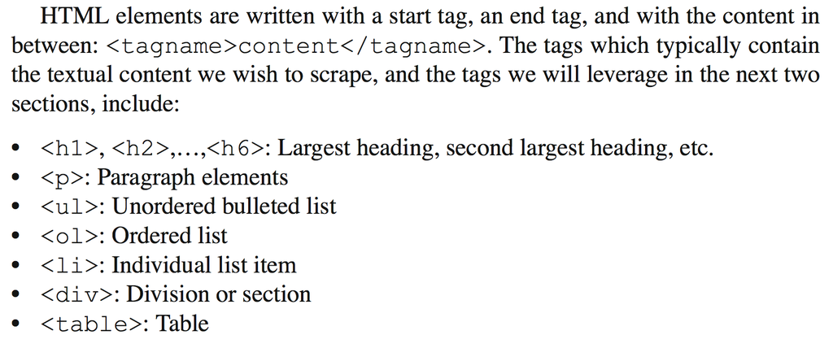

# Extraction via rvest

The `rvest` library is used to extract text and tables. The primary functions that you will use are

- `read_html()`: read in the web page
- `html_nodes()`: extract all text (including HTML code) defined by node boundaries
- `html_text()`: extract the text between the node boundaries
- `html_table()`: extract tabular information

Note that `rvest` is not the only package you could use. Another often-used package is `XML`. If a combination of `rvest` and string manipulation doesn’t easily get you what you want, then definitely explore the Internet (and StackOverflow) to see if other packages exists that will meet your needs.

For more information, see, e.g., *Data Wrangling with R* by Bradley Boehmke and *XML and Web Technologies for Data Sciences with R* by Deborah Nolan and Duncan Temple Lang, both of which are available online via the CMU library.

# Example: Pittsburgh Industries

[figure not shown]

Your goal: to extract the paragraphs associated with “Major Industries and Commercial Activity”. We note that the header is defined via an `<h2>` node, and the text with `<p>` nodes. The first words are “The southwestern Pennsylvania region” and there are five paragraphs in all.

# Example: Pittsburgh Industries

```r
suppressMessages(library(rvest))
page = read_html("https://www.encyclopedia.com/places/united-states-and-canada/us-political-geography/pittsburgh")
page %>% html_nodes("p") %>% html_text() %>% head()
```

```
## [1] ""
## [2] "The southwestern Pennsylvania region, especially the city of Pittsburgh, showed great resiliency and resourcefulness in shifting from an industrial economy to one based on health care, research, hospitality and tourism through the 1990s. Nevertheless, the local economy mirrored the national …
## [3] "Losses in manufacturing jobs were not completely replaced by high tech jobs, as the latter account for only about six percent of jobs in the Pittsburgh MSA. Another reason for loss of jobs and the region's general downward economic trend is that Pittsburgh has one of the highest corporate ta…
## [4] "By far, the largest employment sector for the Pittsburgh area is in health, educational, and social services. Though heavy manufacturing continues to play a part, it employs only 12.3 percent of the work force as of May 2005. Health care, construction, and education all added jobs in 2004. F…
## [5] "Film making is another emerging industry. Major motion pictures made in Pittsburgh include the original Angels in the Outfield, Night of the Living Dead, The Deer Hunter, Flashdance, Gung Ho, The Silence of the Lambs, Lorenzo's Oil, Hoffa, Groundhog Day, The Wonder Boys, and The Mothman Prop…
## [6] "Items and goods produced: fabricated metal products, primary metals, glass products, machinery, food and related products, medical equipment, chemicals, plastics, electronics, software, robotics"
```

OK, this has pretty much what we want…

```r
page %>% html_nodes("p") %>% html_text() %>% head() %>% .[c(2:6)] %>% paste(.,collapse="\n\n") %>% cat()
```

```
## The southwestern Pennsylvania region, especially the city of Pittsburgh, showed great resiliency and resourcefulness in shifting from an industrial economy to one based on health care, research, hospitality and tourism through the 1990s. Nevertheless, the local economy mirrored the national reces…
##
## Losses in manufacturing jobs were not completely replaced by high tech jobs, as the latter account for only about six percent of jobs in the Pittsburgh MSA. Another reason for loss of jobs and the region's general downward economic trend is that Pittsburgh has one of the highest corporate tax rat…
##
## By far, the largest employment sector for the Pittsburgh area is in health, educational, and social services. Though heavy manufacturing continues to play a part, it employs only 12.3 percent of the work force as of May 2005. Health care, construction, and education all added jobs in 2004. Financ…
##
## Film making is another emerging industry. Major motion pictures made in Pittsburgh include the original Angels in the Outfield, Night of the Living Dead, The Deer Hunter, Flashdance, Gung Ho, The Silence of the Lambs, Lorenzo's Oil, Hoffa, Groundhog Day, The Wonder Boys, and The Mothman Prophecie…
##
## Items and goods produced: fabricated metal products, primary metals, glass products, machinery, food and related products, medical equipment, chemicals, plastics, electronics, software, robotics
```

`.[c(2:6])]` means “extract lines 2 through 6.” The `paste()` function call says “paste all the lines together into a single character string, but put paragraph breaks between the lines (which are actually paragraphs).”

# Example: Pittsburgh Employers

```r
page = read_html("https://www.encyclopedia.com/places/united-states-and-canada/us-political-geography/pittsburgh")
(df = page %>% html_nodes("table") %>% .[1] %>% html_table())  # .[1] = "extract the first table"
```

```
## [[1]]
##                                    X1                  X2
## 1            Largest county employers Number of employees
## 2                 UPMC Health Systems              26,700
## 3                     U.S. Government              20,400
## 4        Commonwealth of Pennsylvania              15,900
## 5  West Penn Allegheny Health Systems              10,200
## 6            University of Pittsburgh              10,100
## 7              Mellon Financial Corp.               8,404
## 8  PNC Financial Services Group, Inc.               6,959
## 9                    Allegheny County               6,695
## 10                          USX Corp.               6,300
## 11                  Giant Eagle, Inc.               5,700
## 12    Highmark Blue Cross Blue Shield               5,600
## 13      Eat'n' Park Hospitality Group               4,600
## 14             Verizon Communications               4,400
## 15              USAirways Group, Inc.               4,000
```

The output from `html_table()` is a list of tables.

Notice an issue? The column headers are given as the first row of the table. (And the numbers are actually character strings with commas.) We need to clean up a bit:

```r
new.df = df[[1]]
names(new.df) = new.df[1,]
new.df = new.df[-1,]
rownames(new.df) = as.character(1:nrow(new.df))
y = sapply(new.df[,2],function(x){gsub(",","",x)})
new.df[,2] = as.numeric(y)
new.df
```

```
##              Largest county employers Number of employees
## 1                 UPMC Health Systems               26700
## 2                     U.S. Government               20400
## 3        Commonwealth of Pennsylvania               15900
## 4  West Penn Allegheny Health Systems               10200
## 5            University of Pittsburgh               10100
## 6              Mellon Financial Corp.                8404
## 7  PNC Financial Services Group, Inc.                6959
## 8                    Allegheny County                6695
## 9                           USX Corp.                6300
## 10                  Giant Eagle, Inc.                5700
## 11    Highmark Blue Cross Blue Shield                5600
## 12      Eat'n' Park Hospitality Group                4600
## 13             Verizon Communications                4400
## 14              USAirways Group, Inc.                4000
```